# Chapter 08, Problem Set Key

### 8.1

The basic logistic equation,
$$\frac{\mathrm{d}N}{\mathrm{d}t} = rN\left(\frac{K − N}{K}\right)$$
says that the per capita rate of growth of a population will decrease as a linear function of the density of that population. The biological interpretation of
$$\frac{K−N}{K}$$
is the fraction of the potential environment still available to the population. Suppose that $K = 100$ and $r = 1.2$. Make a graph of $\mathrm{d}N/\mathrm{d}t$ as a function of $N$ for the logistic equation. Now suppose that another species comes along and takes up a quarter of the space originally available. How will the graph change? Repeat for a species that takes up half of the original space.

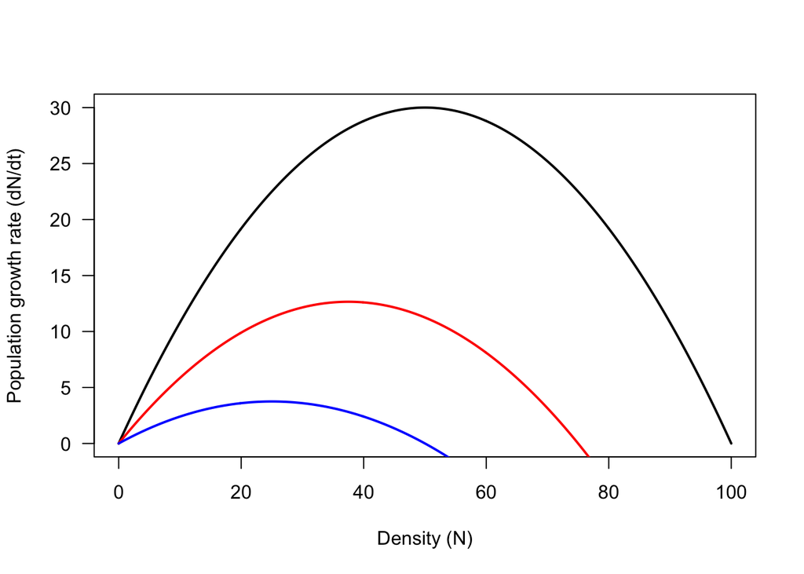

```r
N <- seq(from = 0, to = 100, length.out = 500)
dNdt1 <- 1.2*N*(100 - N)/100
dNdt2 <- 1.2*N*(100*0.75 - N)/100*0.75
dNdt3 <- 1.2*N*(100*0.5 - N)/100*0.5

plot(x = N, y = dNdt1, las = 1, xlab = "Density (N)", ylab = "Population growth rate (dN/dt)", type = "l", lwd = 2)
  lines(x = N, y = dNdt2, lwd = 2, col = "red")
  lines(x = N, y = dNdt3, lwd = 2, col = "blue")
```

### 8.2

Repeat exercise 8.1, but assume that there is a second species that is variable, so that $X$ individuals of this second species will take up $X$ parts of the original space. If you fix $N$ at 50, what will be the relationship between $\mathrm{d}N/\mathrm{d}t$ and X? First make a graph of $\mathrm{d}N/\mathrm{d}t$, and then write the equation describing the situation.

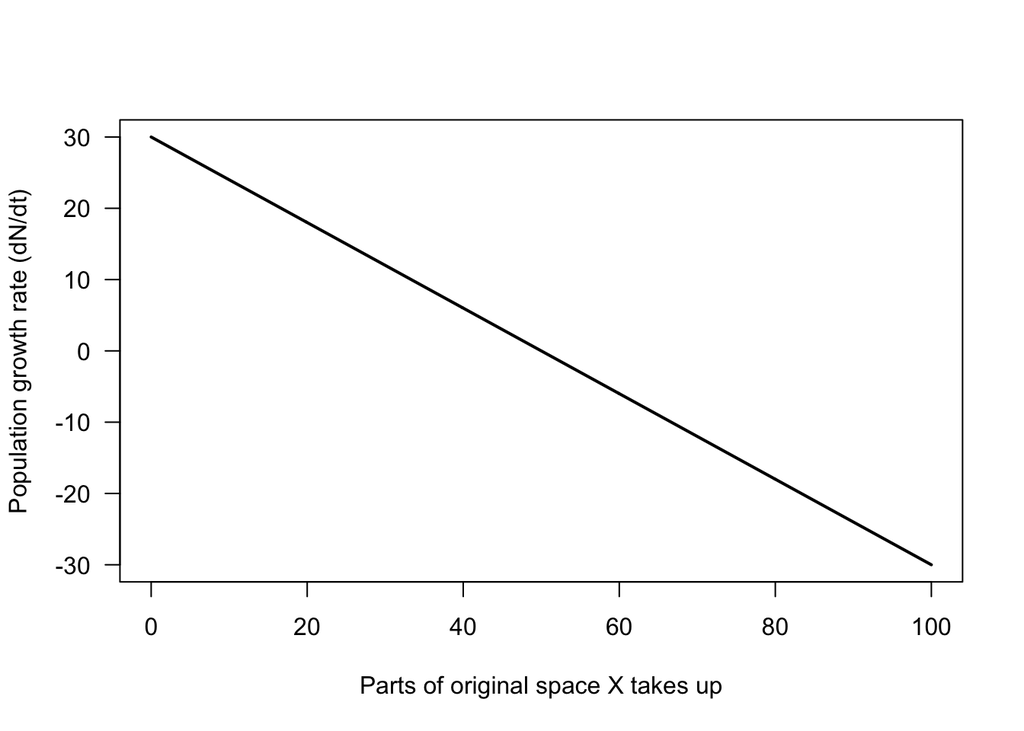

```r
X <- seq(from = 0, to = 100, length.out = 500)
N <- 50 # takes up 50 parts of N
dNdt1 <- 1.2*N*(100 - N - X)/100

plot(x = X, y = dNdt1, las = 1, xlab = "Parts of original space X takes up", ylab = "Population growth rate (dN/dt)", type = "l", lwd = 2)
```

### 8.3

Suppose that each individual of the other species (call its density $X_{8.3}$) takes up only half of the space taken up by each individual of the first species (call its density $N$). Repeat exercise 8.2 but with this new information, and make the graph of $\mathrm{d}N/\mathrm{d}t$ and compare it with the graph of exercise 8.2.

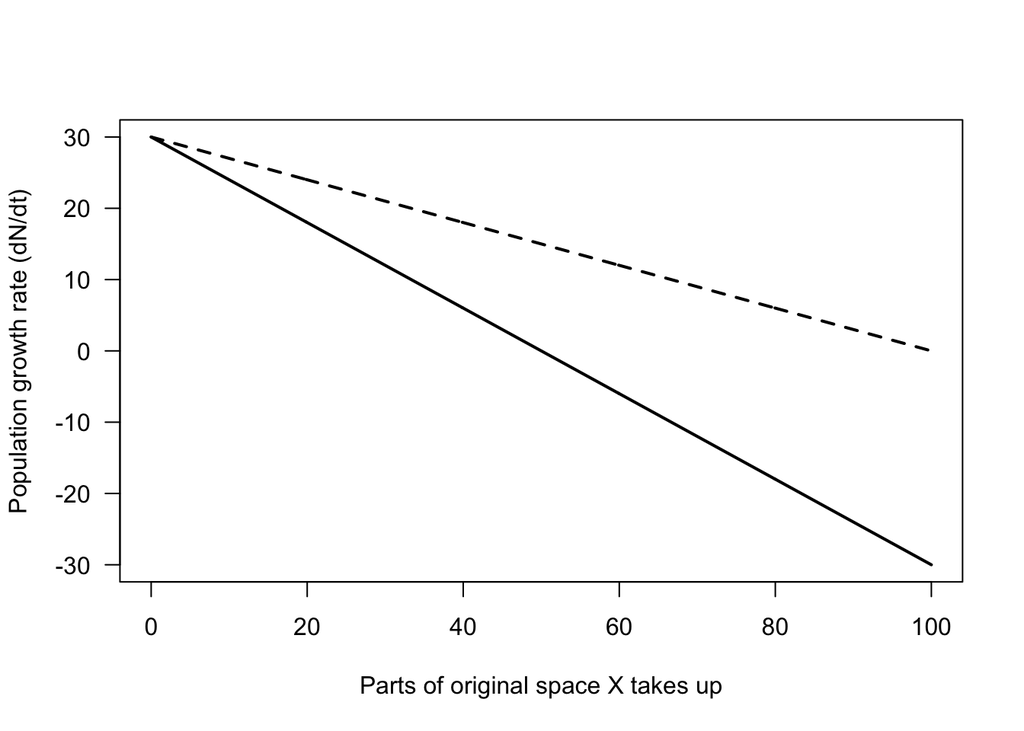

```r
X <- seq(from = 0, to = 100, length.out = 500)
N <- 50 # takes up 50 parts of N
dNdt1 <- 1.2*N*(100 - N - X)/100
dNdt1_1 <- 1.2*N*(100 - N - X*0.5)/100

plot(x = X, y = dNdt1, las = 1, xlab = "Parts of original space X takes up", ylab = "Population growth rate (dN/dt)", type = "l", lwd = 2)
  lines(x = X, y = dNdt1_1, lwd = 2, col = "black", lty = 2)
```

### 8.4

For the information in exercise 8.3, write the differential equation describing $\mathrm{d}N/\mathrm{d}t$ as a function of $N$ and $X$. Set the derivative equal to zero (finding the values for which N will not change), and graph $N$ versus $X$. Suppose the second species ($X$) takes up 90% of the environment of the first species ($N$). Draw the graph, and compare it with the graph of the first case.

$$\frac{\mathrm{d}N}{\mathrm{d}t} = rN\left(\frac{K − N - X(0.9)}{K}\right)$$

### 8.5

Find the equilibria for equations 4a and 4b (set the derivatives to zero and solve), and represent both in terms of $N_1$ as a function of $N_2$.

$$\begin{aligned}
\frac{\mathrm{d}N_1}{\mathrm{d}t} &= r_1N_1\left(\frac{K_1 − N_1 - \alpha _{12}N_2}{K_1}\right) \\
\frac{\mathrm{d}N_2}{\mathrm{d}t} &= r_2N_2\left(\frac{K_2 − N_2 - \alpha _{21}N_1}{K_2}\right)
\end{aligned}$$

For $\frac{\mathrm{d}N_1}{\mathrm{d}t}$, expressed as functions of $N_2$:

$$\begin{aligned}
\frac{\mathrm{d}N_1}{\mathrm{d}t} &= r_1N_1\left(\frac{K_1 − N_1 - \alpha _{12}N_2}{K_1}\right) \\
0 &= r_1N_1\left(\frac{K_1 − N_1 - \alpha _{12}N_2}{K_1}\right) \\
N^{*,1}_1 & = 0 \\
0 &= r_1\left(\frac{K_1 − N_1 - \alpha _{12}N_2}{K_1}\right) \\
0 &= r_1\left(\frac{K_1 − N_1}{K_1}\right) - r_1\frac{\alpha _{12}N_2}{K_1} \\
r_1\frac{\alpha _{12}N_2}{K_1} &= r_1\left(\frac{K_1 − N_1}{K_1}\right) \\
r_1\alpha _{12}N_2 &= r_1K_1 − N_1 \\
\alpha _{12}N_2 &= K_1 − N_1 \\
N_2 &= \frac{K_1 − N_1^{*,2}}{\alpha _{12}}
\end{aligned}$$

And the isocline for $\frac{\mathrm{d}N_2}{\mathrm{d}t}$:

$$\begin{aligned}
\frac{\mathrm{d}N_2}{\mathrm{d}t} &= r_2N_2\left(\frac{K_2 − N_2 - \alpha _{21}N_1}{K_2}\right)\\
0 &= r_2N_2\left(\frac{K_2 − N_2 - \alpha _{21}N_1}{K_2}\right)\\
0 &= r_2N_2\left(\frac{K_2 − N_2 - \alpha _{21}N_1}{K_2}\right)\\
N^{*,1}_2 & = 0 \\
0 &= r_2\left(\frac{K_2 − N_2 - \alpha _{21}N_1}{K_2}\right)\\
0 &= r_2\left(\frac{K_2 - \alpha _{21}N_1}{K_2}\right) -\frac{_2rN_2}{K_2} \\
\frac{r_2N_2}{K_2} &= r_2\left(\frac{K_2 - \alpha _{21}N_1}{K_2}\right) \\
r_2N_2 &= r_2\left(K_2 - \alpha _{21}N_1\right) \\
N_2^{*,2} &= K_2 - \alpha _{21}N_1\\
\end{aligned}$$

### 8.6

Plot both the equations you derived in exercise 8.5 for $\alpha _{12} = 0.8$, $\alpha _{21} = 0.4$, and $K_1 = K_2 = 100$ on the same graph. If you draw a line from the carrying capacity of the first species to the carrying capacity of the second species, what would that mean with regard to the point at which the two isoclines would cross?

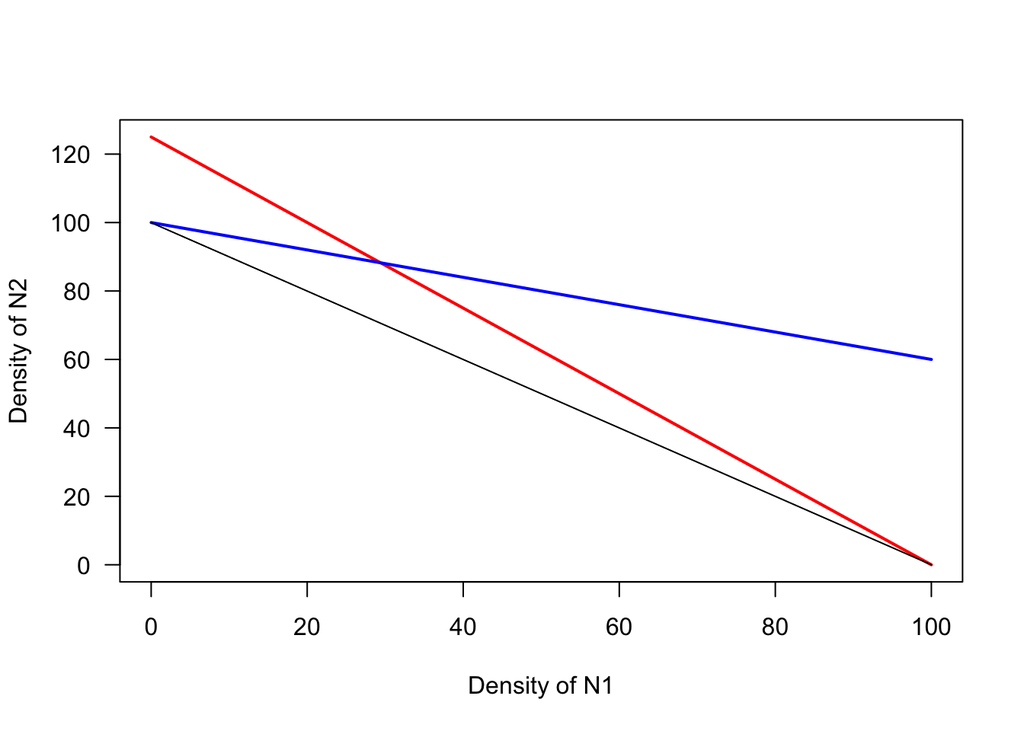

```r
N1 <- seq(from = 0, to = 100, length.out = 100)
alpha12 <- 0.8
alpha21 <- 0.4
K1 <- 100
K2 <- K1

eqn1 <- (K1 - N1)/alpha12
eqn2 <- K2 - alpha21*N1

plot(x = N1, y = eqn1, col = "red", type = "l", las = 1, lwd = 2, xlab = "Density of N1", ylab = "Density of N2")
  lines(x = N1, y = eqn2, col = "blue", lwd = 2)
  segments(x0 = 0, x1 = K1, y0 = K2, y1 = 0)
```

In this example, the joint equilibrium, where $\mathrm{d}N_1/\mathrm{d}t = \mathrm{d}N_2/\mathrm{d}t = 0$, is above the line connecting the two carrying capacities.

### 8.7

Plot both of the equations you derived in 8.5 for $\alpha _{12} = 0.8$, $\alpha _{21} = 0.6$, and $K_1 = K_2 = 150$ on the same graph. Now redraw the equation $N_1 = K_1 – \alpha _{12}N_2$ on the same graph for $K_1 = 200$, and repeat for $K_1 = 100$ and $K_1 = 50$.

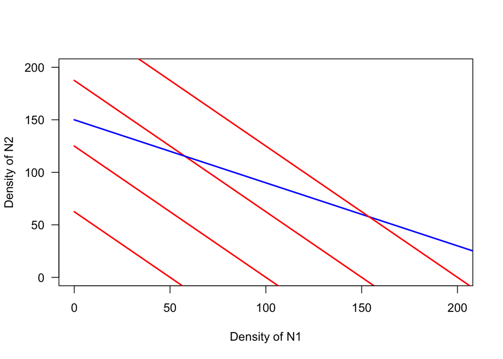

```r
N1 <- seq(from = 0, to = 250, length.out = 100)
alpha12 <- 0.8
alpha21 <- 0.6
K1 <- 150
K2 <- K1

eqn1 <- (K1 - N1)/alpha12
eqn2 <- K2 - alpha21*N1

plot(x = N1, y = eqn1, col = "red", type = "l", las = 1, lwd = 2, xlab = "Density of N1", ylab = "Density of N2", xlim = c(0, 200), ylim = c(0, 200))
  lines(x = N1, y = eqn2, col = "blue", lwd = 2)

otherKs <- c(K1 = 200, K1 = 100, K1 = 50)

for (i in 1:length(otherKs)) {
  eqn1 <- (otherKs[i] - N1)/alpha12
  lines(x = N1, y = eqn1, col = "red", lwd = 2)
}
```

In this example, the joint equilibrium, where $\mathrm{d}N_1/\mathrm{d}t = \mathrm{d}N_2/\mathrm{d}t = 0$, is above the line connecting the two carrying capacities.

### 8.8

Repeat exercise 8.7 for $\alpha _{12}$ = 1.3 and $\alpha _{21} = 1.2$.

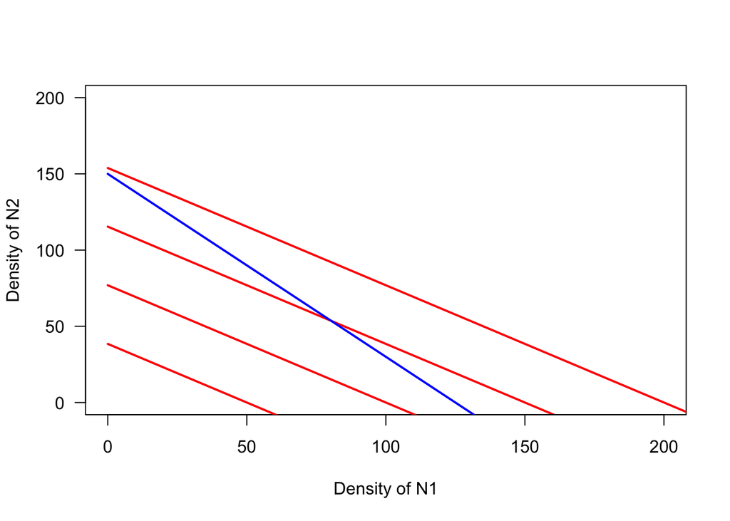

```r
N1 <- seq(from = 0, to = 250, length.out = 100)
alpha12 <- 1.3
alpha21 <- 1.2
K1 <- 150
K2 <- K1

eqn1 <- (K1 - N1)/alpha12
eqn2 <- K2 - alpha21*N1

plot(x = N1, y = eqn1, col = "red", type = "l", las = 1, lwd = 2, xlab = "Density of N1", ylab = "Density of N2", xlim = c(0, 200), ylim = c(0, 200))
  lines(x = N1, y = eqn2, col = "blue", lwd = 2)

otherKs <- c(K1 = 200, K1 = 100, K1 = 50)

for (i in 1:length(otherKs)) {
  eqn1 <- (otherKs[i] - N1)/alpha12
  lines(x = N1, y = eqn1, col = "red", lwd = 2)
}
```

### 8.9

Suppose that there are two competing species with $K_1 = 95$, $K_2 = 80$, $\alpha _{12} = 1.1$, and $\alpha _{21} = 0.75$. Graph the isoclines, and identify (graphically) the stable and unstable equilibrium points. Repeat for $K_1 = 95$, $K_2 = 80$, $\alpha _{12} = 0.75$, and $\alpha _{21} = 1.1$ and for $K_1 = 100$, $K_2 =95$, $\alpha _{12} =1.2$, and $\alpha _{21} =1.1$.

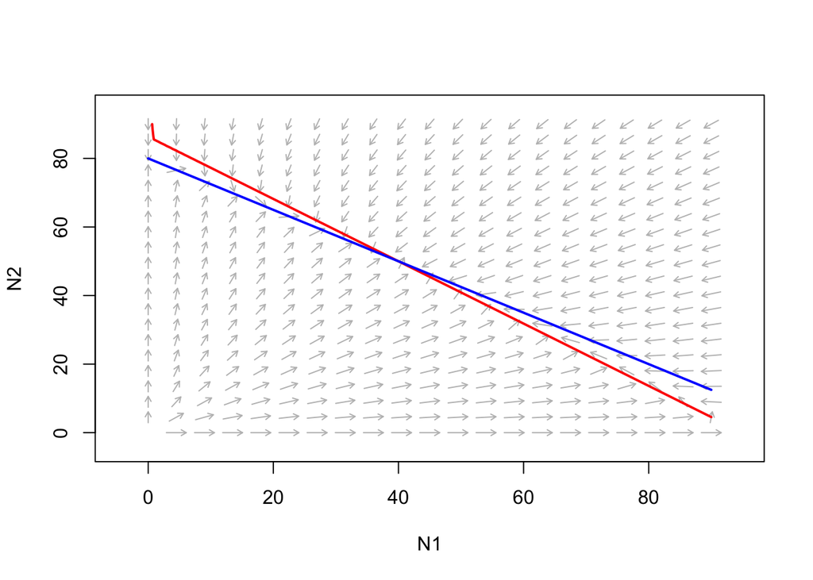

```r
comp <- function(t, y, parms) {
  with(as.list(c(y, parms)), {
    dN1 <- r*N1*(K1 - N1 - alpha12*N2)/K1
    dN2 <- r*N2*(K2 - N2 - alpha21*N1)/K2
    return(list(c(dN1, dN2)))
  })
}

parms.vec <- c(K1 = 95, K2 = 80, alpha12 = 1.1, alpha21 = 0.75, r = 1)
y.names = c("N1", "N2")
axis.lims <- c(0, 90)

ff.out <- flowField(deriv = comp, parameters = parms.vec, xlim = axis.lims, ylim = axis.lims, add = F, xlab = "N1", ylab = "N2", state.names = y.names)
nc.out <- nullclines(deriv = comp, parameters = parms.vec, xlim = axis.lims, ylim = axis.lims, add = T, xlab = "N1", ylab = "N2", state.names = y.names, col = c("red", "blue"), lwd = 2, add.legend = F)
```

### 8.10

Repeat exercise 8.9 for $K_1 = 95$, $K_2 = 80$, $\alpha _{12} = 1.1$, and $\alpha _{21} = 0.75$ and for $K_1 = 100$, $K_2 = 95$, $\alpha _{12} = 1.2$, and $\alpha _{21} = 1.1$. On each graph sketch in the equation $N_2 = K_2 − (K_2/K_1)N_1$. Where does the equilibrium point lie in each case?

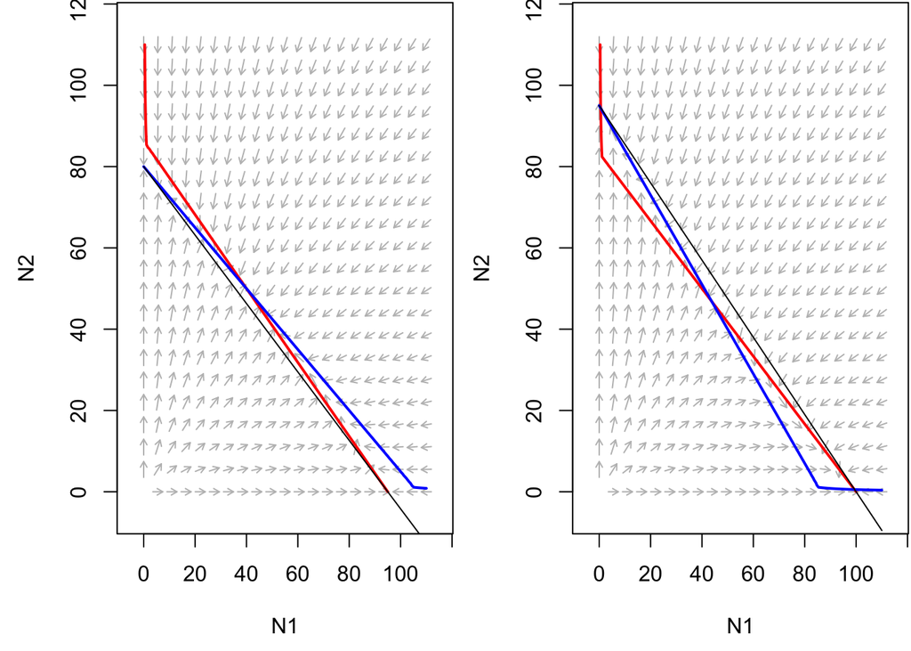

```r
comp <- function(t, y, parms) {
  with(as.list(c(y, parms)), {
    dN1 <- r*N1*(K1 - N1 - alpha12*N2)/K1
    dN2 <- r*N2*(K2 - N2 - alpha21*N1)/K2
    return(list(c(dN1, dN2)))
  })
}

parms.vec <- c(K1 = 95, K2 = 80, alpha12 = 1.1, alpha21 = 0.75, r = 1)
parms.vec_1 <- c(K1 = 100, K2 = 95, alpha12 = 1.2, alpha21 = 1.1, r = 1)
y.names = c("N1", "N2")
axis.lims <- c(0, 110)

N1_vec <- seq(from = 0, to = 110, length.out = 100 )
N2_vec <- parms.vec["K2"] - (parms.vec["K2"]/parms.vec["K1"])*N1_vec
N2_vec_1 <- parms.vec_1["K2"] - (parms.vec_1["K2"]/parms.vec_1["K1"])*N1_vec

par(mfrow = c(1, 2), mar = c(4.5, 4.5, 0.1, 0.1))
ff.out <- flowField(deriv = comp, parameters = parms.vec, xlim = axis.lims, ylim = axis.lims, add = F, xlab = "N1", ylab = "N2", state.names = y.names)
nc.out <- nullclines(deriv = comp, parameters = parms.vec, xlim = axis.lims, ylim = axis.lims, add = T, xlab = "N1", ylab = "N2", state.names = y.names, col = c("red", "blue"), lwd = 2, add.legend = F)
lines(x = N1_vec, y = N2_vec)

ff.out <- flowField(deriv = comp, parameters = parms.vec_1, xlim = axis.lims, ylim = axis.lims, add = F, xlab = "N1", ylab = "N2", state.names = y.names)
nc.out <- nullclines(deriv = comp, parameters = parms.vec_1, xlim = axis.lims, ylim = axis.lims, add = T, xlab = "N1", ylab = "N2", state.names = y.names, col = c("red", "blue"), lwd = 2, add.legend = F)
lines(x = N1_vec, y = N2_vec_1)
```

For 8.9 the equilibrium is above the lines and 8.10 it is below. They respectively represent stable and unstable equilibria.

### 8.11

On a coffee farm in southern Mexico, ants were sampled at five different heights in the vegetation, 0, 1, 2, 3, and 4 meters (0 was on the ground). Three species of ants were encountered, *Pheidole protensa* (*P*), *Pheidole synanthropica* (*S*), and *Crematogaster carinata* (*C*). The proportional distribution of all the sampling sites at which a particular species was encountered was as follows:

| Height | *P* | *S* | *C* |
| --- | --- | --- | --- |
| 0 | 90 | 30 | 0 |
| 1 | 10 | 55 | 0 |
| 2 | 0 | 13 | 2 |
| 3 | 0 | 2 | 18 |
| 4 | 0 | 0 | 80 |

Graph the abundances as a function of position in the vegetation for all three species. What can you hypothesize about the competitive interaction among the three species based on these observations?

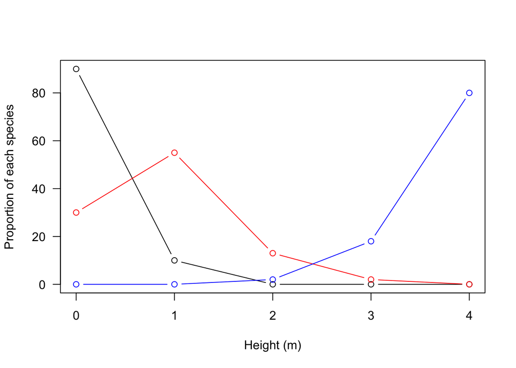

```r
height <- 0:4
P <- c(90, 10, 0, 0, 0)
S <- c(30, 55, 13, 2, 0)
C <- c(0, 0, 2, 18, 80)

plot(x = height, y = P, type = "b", las = 1, xlab = "Height (m)", ylab = "Proportion of each species")
points(x = height, y = S, col = "red", type = "b")
points(x = height, y = C, col = "blue", type = "b")
```

Based on the relative abundaces of the three species, we could hypothesize that they are unequally distributed across the height of the tree. Because species are distributed unevenly through space means that there could be environmental differences, competitive differences, or other biotic interactions could be mediating the differences (e.g., apparent competition, mutualism).

### 8.12

Two other sites were located on the same farm, one at which *C* was absent and one at which *S* was absent. The same classes of data for these two sites were as follows:

| Height | *P* | *S* | *C* |
| --- | --- | --- | --- |
| 0 | 90 | 5 | 0 |
| 1 | 10 | 10 | 0 |
| 2 | 0 | 15 | 0 |
| 3 | 0 | 30 | 0 |
| 4 | 0 | 40 | 0 |

and

| Height | *P* | *S* | *C* |
| --- | --- | --- | --- |
| 0 | 70 | 0 | 0 |
| 1 | 25 | 0 | 0 |
| 2 | 5 | 0 | 2 |
| 3 | 0 | 0 | 18 |
| 4 | 0 | 0 | 80 |

Graph the abundances as a function of position in the vegetation for all three species at both sites. What can you now hypothesize about the competitive interactions among the three species using the above data and the observations from exercise 8.9?

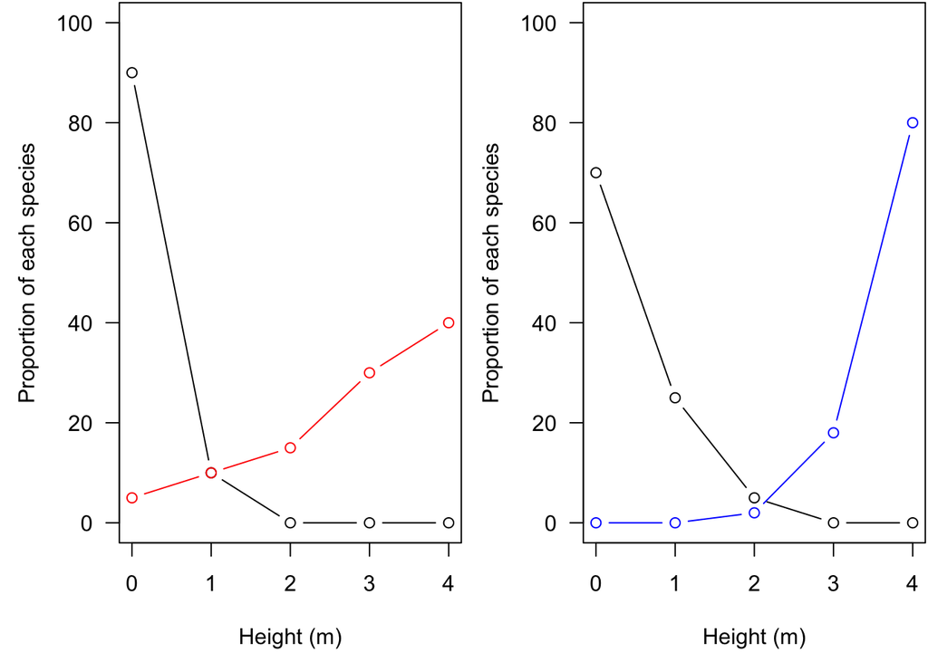

```r
height <- 0:4
P <- c(90, 10, 0, 0, 0)
S <- c(5, 10, 15, 30, 40)

P1 <- c(70, 25, 5, 0, 0)
C <- c(0, 0, 2, 18, 80)

par(mfrow = c(1, 2), mar = c(4.5, 4.5, 0.1, 0.1))
plot(x = height, y = P, type = "b", las = 1, xlab = "Height (m)", ylab = "Proportion of each species", ylim = c(0, 100))
points(x = height, y = S, col = "red", type = "b")

plot(x = height, y = P1, type = "b", las = 1, xlab = "Height (m)", ylab = "Proportion of each species", ylim = c(0, 100))
points(x = height, y = C, col = "blue", type = "b")
```

*Pheidole protensa* is found at lower heights in trees, while *Pheidole synanthropica* and *Crematogaster carinata* are found at higher heights in trees. When either *Pheidole synanthropica* of *Crematogaster carinata* are absent, the other occupies higher parts of the tree. When all three are together,*Pheidole protensa* occupies the lowest parts, *Pheidole synanthropica* occupies mid-heights, and *Crematogaster carinata* occupies the highest parts of the trees.